# CM3015 - ML&NN: MIDTERMS

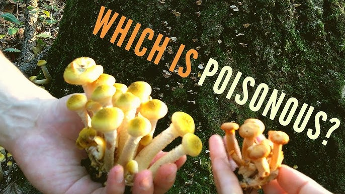

## Aim

The main focus of this project is to compare two ML algorithms, k-Nearest Neighbours (kNN) vs. Decision Trees, in their abilities to classify accurately if a mushrooom is edible or poisonous based on its physical characteristics.

## Dataset Overview

The dataset is a csv file of Mushroom Classification, distinguishing hypothetical samples of 23 species of gilled mushrooms in the Agaricus and Lepiota Family Mushroom drawn from The Audubon Society Field Guide to North American Mushrooms (1981). The mushrooms are identified as **edible** or **poisonous** based on their physical attributes.

The data features 22 categorical attributes, for example:

- **Cap Shape**: bell, conical, flat, etc.
- **Odor: foul**, anise, almond, etc.
- **Gill Color**: brown, buff, black, etc.
- **Spore Print Color**: brown buff, black, etc.

The mushrooms are labelled:

- **e** (Edible)
- **p** (Poisonous)

## Import Tools

```python
import pandas as pd
from sklearn.model_selection import train_test_split
from sklearn.preprocessing import LabelEncoder
```

## Load Dataset

```python
file_path = 'mushrooms.csv'
df = pd.read_csv(file_path)
```

## Check Dataset

```python
print(df.head())
print(df.info())
print(df.describe())
```

```
  class cap-shape cap-surface cap-color bruises odor gill-attachment  \
0     p         x           s         n       t    p               f
1     e         x           s         y       t    a               f
2     e         b           s         w       t    l               f
3     p         x           y         w       t    p               f
4     e         x           s         g       f    n               f

  gill-spacing gill-size gill-color  ... stalk-surface-below-ring  \
0            c         n          k  ...                        s
1            c         b          k  ...                        s
2            c         b          n  ...                        s
3            c         n          n  ...                        s
4            w         b          k  ...                        s

  stalk-color-above-ring stalk-color-below-ring veil-type veil-color  \
0                      w                      w         p          w
1                      w                      w         p          w
2                      w                      w         p          w
3                      w                      w         p          w
4                      w                      w         p          w

  ring-number ring-type spore-print-color population habitat
0           o         p                 k          s       u
1           o         p                 n          n       g
2           o         p                 n          n       m
3           o         p                 k          s       u
4           o         e                 n          a       g

[5 rows x 23 columns]
<class 'pandas.core.frame.DataFrame'>
RangeIndex: 8124 entries, 0 to 8123
Data columns (total 23 columns):
 #   Column                    Non-Null Count  Dtype
---  ------                    --------------  -----
 0   class                     8124 non-null   object
 1   cap-shape                 8124 non-null   object
 2   cap-surface               8124 non-null   object
 3   cap-color                 8124 non-null   object
 4   bruises                   8124 non-null   object
 5   odor                      8124 non-null   object
```

[output cut: 30 more lines]

```
freq           6812      5612       1728  ...                     4936

       stalk-color-above-ring stalk-color-below-ring veil-type veil-color  \
count                    8124                   8124      8124       8124
unique                      9                      9         1          4
top                         w                      w         p          w
freq                     4464                   4384      8124       7924

       ring-number ring-type spore-print-color population habitat
count         8124      8124              8124       8124    8124
unique           3         5                 9          6       7
top              o         p                 w          v       d
freq          7488      3968              2388       4040    3148

[4 rows x 23 columns]
```

## Data Structure and Characteristics (observed from above)

The dataset consists of **23 columns** and **8,124 rows**, where the **class** column serves as the target variable, and the remaining 22 columns represent **categorical features**. All columns are **non-numeric**, as each feature describes a categorical property of mushrooms. Upon inspection using the Pandas library, it was observed that **no missing values** are present, ensuring a complete dataset for analysis. This attribute eliminates the need for imputation or handling of null values, streamlining the preprocessing phase.

The class column, the target variable, is balanced, with **4,208 observations labeled as edible** (e) and **3,916 labeled as poisonous (p)**. This balance ensures that the models trained on this data **will not be biased** toward one class, making it well-suited for binary classification tasks.

## PreProcessing

```python
print("Missing values:\n", df.isnull().sum())  # Check for missing values
df = df.dropna()  # Drop rows with missing values (if any)

# Encode Categorical Features
label_encoders = {}
for column in df.columns:
    if df[column].dtype == 'object':  # Check if the column is categorical
        le = LabelEncoder()
        df[column] = le.fit_transform(df[column])
        label_encoders[column] = le
```

```
Missing values:
 class                       0
cap-shape                   0
cap-surface                 0
cap-color                   0
bruises                     0
odor                        0
gill-attachment             0
gill-spacing                0
gill-size                   0
gill-color                  0
stalk-shape                 0
stalk-root                  0
stalk-surface-above-ring    0
stalk-surface-below-ring    0
stalk-color-above-ring      0
stalk-color-below-ring      0
veil-type                   0
veil-color                  0
ring-number                 0
ring-type                   0
spore-print-color           0
population                  0
habitat                     0
dtype: int64
```

This confirms there are no missing values.

## Split the data = 80% Training, 20% Testing

```python
X = df.drop(columns=['class'])  # Features
y = df['class']  # Target variable

X_train, X_test, y_train, y_test = train_test_split(X, y, test_size=0.2, random_state=42)

print("Training set shape:", X_train.shape)
print("Test set shape:", X_test.shape)
```

```
Training set shape: (6499, 22)
Test set shape: (1625, 22)
```

## Implement k-Nearest Neighbours (kNN) on dataset

```
Accuracy for k=85: 0.95
```

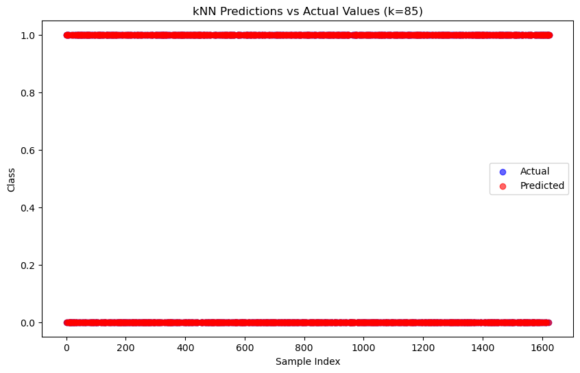

```python
import numpy as np
from collections import Counter
import matplotlib.pyplot as plt

# Function to calculate Euclidean distance
def euclidean_distance(x1, x2):
    return np.sqrt(np.sum((x1 - x2) ** 2))

# kNN Algorithm
class KNN:
    def __init__(self, k=81):
        # Ensure k is odd
        if k % 2 == 0:
            raise ValueError("k must be an odd number.")
        self.k = k

    def fit(self, X, y):
        # Input validation
        if len(X) != len(y):
            raise ValueError("The number of samples in X and y must be the same.")
        self.X_train = np.array(X)
        self.y_train = np.array(y)

    def predict(self, X):
        X = np.array(X)
        predictions = [self._predict(x) for x in X]
        return np.array(predictions)

    def _predict(self, x):
        # Compute distances
        distances = [euclidean_distance(x, x_train) for x_train in self.X_train]
        # Get indices of the k-nearest neighbors
        k_indices = np.argsort(distances)[:self.k]
        # Get the classes of the k-nearest neighbors
        k_neighbor_labels = [self.y_train[i] for i in k_indices]
        # Determine the majority class
        most_common = Counter(k_neighbor_labels).most_common(1)
        return most_common[0][0]

# Set a single value for k
k = 85  # Adjust this value as needed

# Instantiate and fit the kNN classifier
knn = KNN(k=k)
knn.fit(X_train, y_train)

# Predict on the test set
y_pred = knn.predict(X_test)

# Evaluate accuracy
accuracy = np.sum(y_pred == y_test.values) / len(y_test)
print(f"Accuracy for k={k}: {accuracy:.2f}")

# Plot actual vs predicted
plt.figure(figsize=(10, 6))
plt.scatter(range(len(y_test)), y_test, color='blue', alpha=0.6, label='Actual')
plt.scatter(range(len(y_test)), y_pred, color='red', alpha=0.6, label='Predicted')
plt.title(f'kNN Predictions vs Actual Values (k={k})')
plt.xlabel('Sample Index')
plt.ylabel('Class')
plt.legend()
plt.show()
```

## Evaluation of kNN Implementation

Using a training set of 6,499 samples and a testing set of 1,625 samples, the value of k was set to 85 based on the square root rule and experimentation. The model generated an accuracy rate of 95%, indicating that it correctly classified 95% of the mushrooms in the test. I'm assuming the high accuracy rate was due to several factors -

1. **Simplicity of Dataset**: the classification of mushrooms have distinct feature patterns for edible and poisonous mushrooms, hence it as easy for the kNN algorithm distinguish between the 2 classes.
2. **Balanced dataset**: The dataset has an almost even distribution between the 2 classes, reducing risk of bias towards one particular class.

However, I might consider using cross-validation to confirm if this accuracy result is not just coincidence with the current split of the data. But for this project, I would like to measure the overall correctness of the kNN model's prediction to evaluate it further.

```python
from sklearn.metrics import precision_score, recall_score, f1_score, classification_report

# Predict using the kNN model
y_pred = knn.predict(X_test)

# Calculate metrics
precision = precision_score(y_test, y_pred, average='binary')  # Use 'weighted' or 'macro' for multiclass
recall = recall_score(y_test, y_pred, average='binary')
f1 = f1_score(y_test, y_pred, average='binary')

print(f"Precision: {precision:.2f}")
print(f"Recall: {recall:.2f}")
print(f"F1-Score: {f1:.2f}")

# Alternatively, print a classification report
print(classification_report(y_test, y_pred))
```

```
Precision: 0.99
Recall: 0.91
F1-Score: 0.95
              precision    recall  f1-score   support

           0       0.92      0.99      0.95       843
           1       0.99      0.91      0.95       782

    accuracy                           0.95      1625
   macro avg       0.95      0.95      0.95      1625
weighted avg       0.95      0.95      0.95      1625
```

The performance of the k-Nearest Neighbors (kNN) model was evaluated using precision, recall, and F1-score, providing a comprehensive view of its classification effectiveness. The model achieved an overall accuracy of 95%, with a precision of 0.99 and a recall of 0.91, resulting in a balanced F1-score of 0.95. This indicates that the model is highly effective at correctly identifying positive cases (poisonous mushrooms) with minimal false positives.

Specifically, for class 0 (edible mushrooms), the model achieved a precision of 0.92 and a recall of 0.99, reflecting a strong ability to correctly classify most edible mushrooms while keeping false negatives low. Conversely, for class 1 (poisonous mushrooms), the model attained a precision of 0.99 and a recall of 0.91, signifying high confidence in identifying poisonous mushrooms while occasionally missing a few.

## Implement Decision Tree Classifier on dataset

```
Decision Tree Accuracy: 1.00
Tree Depth: 7
Number of Leaves: 18
```

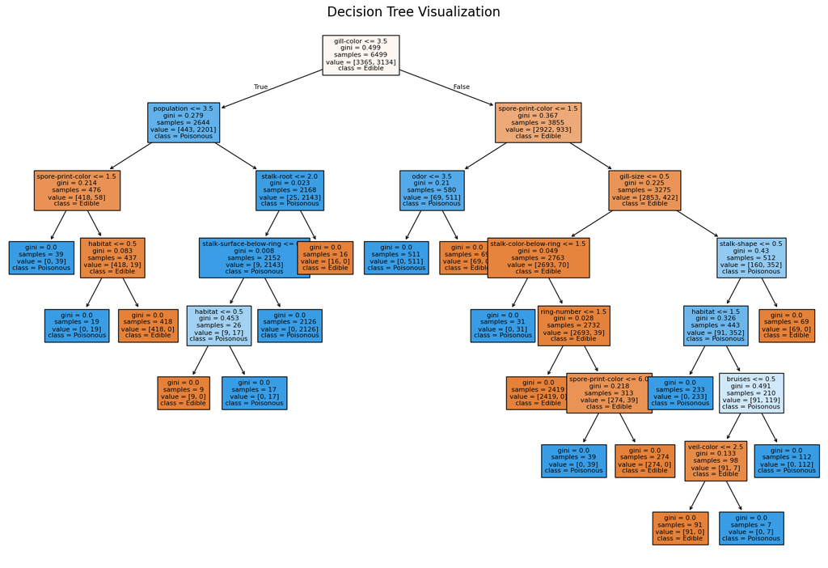

```python
from sklearn.tree import DecisionTreeClassifier
from sklearn.metrics import accuracy_score
import matplotlib.pyplot as plt
from sklearn.tree import plot_tree

# Instantiate the Decision Tree Classifier
dt = DecisionTreeClassifier(random_state=42)

# Train the model
dt.fit(X_train, y_train)

# Predict on the test set
y_pred = dt.predict(X_test)

# Calculate and display accuracy
accuracy = accuracy_score(y_test, y_pred)
print(f"Decision Tree Accuracy: {accuracy:.2f}")
print(f"Tree Depth: {dt.get_depth()}")
print(f"Number of Leaves: {dt.get_n_leaves()}")

# Visualize the Decision Tree
plt.figure(figsize=(18, 12))
plot_tree(
    dt,
    feature_names=X.columns,
    class_names=['Edible', 'Poisonous'],
    filled=True,
    fontsize=8
)
plt.title("Decision Tree Visualization", fontsize=16)
plt.show()
```

## Feature Importance in Decision Tree

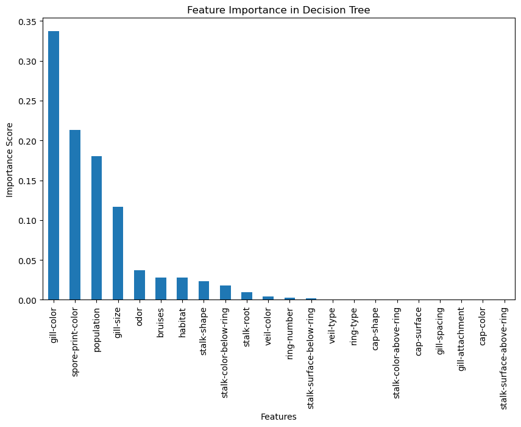

```
gill-color                  0.336926
spore-print-color           0.213026
population                  0.180644
gill-size                   0.116717
odor                        0.037463
bruises                     0.027773
habitat                     0.027608
stalk-shape                 0.023229
stalk-color-below-ring      0.018354
stalk-root                  0.009706
veil-color                  0.004006
ring-number                 0.002652
stalk-surface-below-ring    0.001897
veil-type                   0.000000
ring-type                   0.000000
cap-shape                   0.000000
stalk-color-above-ring      0.000000
cap-surface                 0.000000
gill-spacing                0.000000
gill-attachment             0.000000
cap-color                   0.000000
stalk-surface-above-ring    0.000000
dtype: float64
```

```python
import pandas as pd
feature_importances = pd.Series(dt.feature_importances_, index=X.columns)
feature_importances = feature_importances.sort_values(ascending=False)

plt.figure(figsize=(10, 6))
feature_importances.plot(kind='bar')
plt.title("Feature Importance in Decision Tree")
plt.xlabel("Features")
plt.ylabel("Importance Score")
plt.show()

print(feature_importances)
```

```python
from sklearn.tree import DecisionTreeClassifier
from sklearn.metrics import accuracy_score, precision_score, recall_score, f1_score, classification_report
import matplotlib.pyplot as plt
from sklearn.tree import plot_tree

# Evaluate the model
accuracy = accuracy_score(y_test, y_pred)
precision = precision_score(y_test, y_pred, average='binary')  # Use 'binary' or 'weighted' as appropriate
recall = recall_score(y_test, y_pred, average='binary')
f1 = f1_score(y_test, y_pred, average='binary')

# Print the evaluation metrics
print("=== Decision Tree Evaluation Results ===")
print(f"Accuracy: {accuracy:.2f}")
print(f"Precision: {precision:.2f}")
print(f"Recall: {recall:.2f}")
print(f"F1-Score: {f1:.2f}\n")

# Detailed classification report
print("=== Classification Report ===")
print(classification_report(y_test, y_pred))S
```

```
=== Decision Tree Evaluation Results ===
Accuracy: 1.00
Precision: 1.00
Recall: 1.00
F1-Score: 1.00

=== Classification Report ===
              precision    recall  f1-score   support

           0       1.00      1.00      1.00       843
           1       1.00      1.00      1.00       782

    accuracy                           1.00      1625
   macro avg       1.00      1.00      1.00      1625
weighted avg       1.00      1.00      1.00      1625
```

## Evaluation of Decision Tree Implementation

As demonstrated in the graphs and reports above, the Decision Tree algorithm achieved perfect accuracy in classifying mushrooms as either edible or poisonous. The accompanying precision, recall, and F1-score results further validate this good result.

The bar chart highlights that the Decision Tree model identified gill color as the most important feature for classification. This is because gill color provided the greatest reduction in Gini impurity during the splits, meaning it offered the clearest separation between edible and poisonous mushrooms.

## Comparison of kNN vs. Decision Tree results

Although both kNN and Decision Tree algorithms are used for classification tasks, they operate in fundamentally different ways.

kNN does not create rules or ask questions. Instead, it identifies the closest examples in the training data to make predictions. When classifying a new mushroom, kNN calculates the similarity or distance between the new mushroom and every other mushroom in the training set. It then identifies the k nearest neighbors. If the majority of these neighbors are poisonous, the algorithm predicts the new mushroom is poisonous; if the majority are edible, it predicts the mushroom is edible.

In contrast, Decision Trees take a rule-based approach. Rather than comparing the new mushroom to surrounding examples, the Decision Tree asks a series of binary yes-or-no questions to classify it. Depending on the answer to each question, the algorithm moves down one branch of the tree until it reaches a final decision: edible or poisonous. The Decision Tree learns these “rules” from the training data and applies them during prediction. Unlike kNN, which relies directly on the training data, the Decision Tree does not need to reference the training set once it has built the tree.

Comparing these two methods, Decision Tree is generally more efficient for larger datasets. Once trained, it uses its learned rules to make predictions very quickly, as it does not rely on computing distances for each new data point. kNN, on the other hand, can struggle with large datasets, as its prediction process requires calculating distances for every test point against all training points, making it slower and potentially less accurate in such cases.

In conclusion, the Decision Tree outperformed kNN in this case, achieving perfect accuracy (100%) compared to kNN’s 95%. This difference is likely due to the size and structure of the dataset, which allowed the Decision Tree to effectively learn and apply clear classification rules.